# Regression Models - Assignment

Benil Mathew

22 October 2016

### Executive Summary

This report is a R markdown of the peer-graded assignment for Regression Models Coursera course.

The analysis in this assignment attempts to answer the following questions based on the `mtcars` dataset:  
- Is an automatic or manual transmission better for MPG?  
- Quantify the MPG difference between automatic and manual transmissions

Based on the analysis MPG changes by 14.0794278 + -4.1413764 * weight (in 1000 lbs) for manual transmission in comparison with automatic transmission, when 1/4 mile time and weight are held constant. Below a weight of 3399.698 lbs manual transmission is better for MPG, but for weight above this value, automatic transmission is better.

### The analysis

The `mtcars` dataset include data that was extracted from the 1974 Motor Trend US magazine, comprising of fuel consumption and 10 other aspects of automobile design and performance for 32 automobiles (1973–74 models). The features in the dataset are - `mpg` - Miles/(US) gallon, `cyl` - Number of cylinders, `disp` - Displacement (cu.in.), `hp` - Gross horsepower, `drat` - Rear axle ratio, `wt` - Weight (1000 lbs), `qsec` - 1/4 mile time, `vs` - V/S, `am` - Transmission (0 = automatic, 1 = manual), `gear` - Number of forward gears, `carb` - Number of carburetors

#### Loading the data

```r
library(ggplot2)
data(mtcars)
```

Convert features to factors

```r
mtcars$cyl <- as.factor(mtcars$cyl); mtcars$vs <- as.factor(mtcars$vs);
mtcars$am <- as.factor(mtcars$am); mtcars$gear <- as.factor(mtcars$gear);
mtcars$carb <- as.factor(mtcars$carb)
```

**Following are the steps followed in identifying the best possible model to identify how `am` affects `mpg`**  
Plot a pairs plot of key variables that are expected affect `mpg`  
1. Determine parameters to include based on what was identified in the pairs plot  
2. Run model  
3. Assess the p-value for the coefficients, Adjusted R squared and Residual standard error for the degrees of freedom  
4. If untried alternate models exist, go to step 1

Based on the assessment, the model chosen include `am`, `wt`, `qsec` and an interaction between `wt` and `am` - lm(mpg ~ am + wt + qsec + wt*am, data = mtcars). Output of the key factors assessed are shown here:

```
##              Estimate Std. Error   t value     Pr(>|t|)
## (Intercept)  9.723053  5.8990407  1.648243 0.1108925394
## am1         14.079428  3.4352512  4.098515 0.0003408693
## wt          -2.936531  0.6660253 -4.409038 0.0001488947
## qsec         1.016974  0.2520152  4.035366 0.0004030165
## am1:wt      -4.141376  1.1968119 -3.460340 0.0018085763
```

Low p-values for the coeficients (except the Intercept), showing a high level of signficance at 0.95 significance level.  
Based on the adjusted R squared the model explains `88%` of the variance  
Residual standard error with this model is `2.0841223` at `27` degrees of freedom

### Conslusion

- Is an automatic or manual transmission better for MPG?  
  - This will depend on the `wt` of the car. Below `wt` of 3.399698 manual transmission is better for MPG, but for `wt` above this value, automatic transmission is better.
- Quantify the MPG difference between automatic and manual transmissions  
  - MPG changes by `14.0794278 + -4.1413764 * wt` for manual transmission in comparison with automatic transmission, when `qsec` and `wt` are held constant.

Various models that assessed in the process are shown below. Appendix shows some explorator analysis and assessment of final model.  
1. lm(mpg ~ am, data = mtcars)  
2. lm(mpg ~ ., data = mtcars)  
3. lm(mpg ~ am + wt, data = mtcars)  
4. lm(mpg ~ am + wt + disp, data = mtcars)  
5. lm(mpg ~ am + wt + qsec, data = mtcars)  
6. lm(mpg ~ am + wt + qsec + wtcyl, data = mtcars)  
7. lm(mpg ~ am + wt + qsec + wtdisp, data = mtcars)  
8. lm(mpg ~ am + wt + qsec + wtam, data = mtcars)  
9. lm(mpg ~ am + wt + qsec + wtam + qseccyl, data = mtcars)  
10. lm(mpg ~ am + disp, data = mtcars)  
11. lm(mpg ~ am + disp + qsec + wtam, data = mtcars)

### Appendix

#### Pair plot of key variables that are expected to impact mpg

Plot of features that are expected to have an impact on mpg

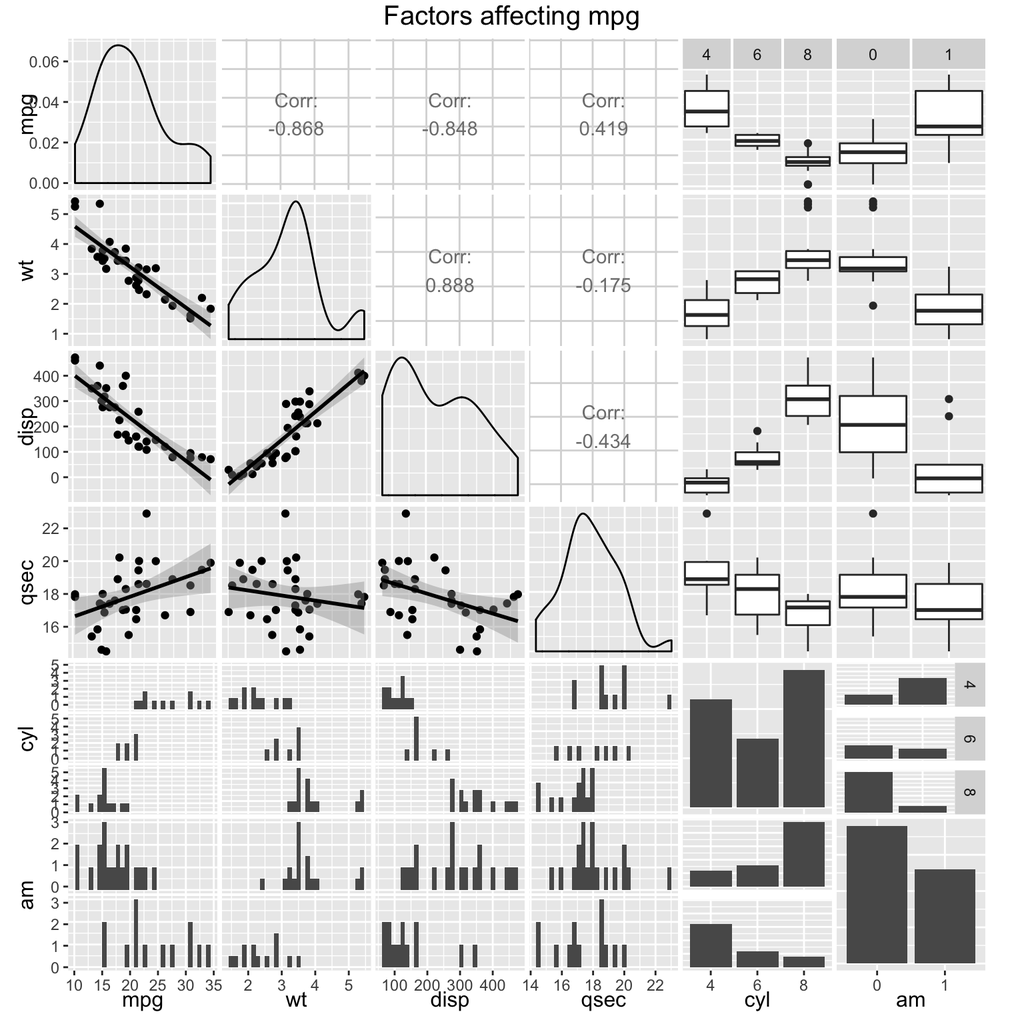

**Some initial observations, from the plot, that may be relevant in decidnig inclusion or exclusion of features in the model:**  
* Both am and cyl seem to have an effect on mpg  
* mpg is negatively correlated with wt and disp, at -0.87 and -0.85 respectively. Inclusion of both in the model may impact the fit, but one of them  
* mpg is positively correlated with qsec, but is relatively weak at 0.42, a potential candidate for inclusion in the model  
* wt seems to be affected by am, hence may be a factor to be considered in the model  
* Highest correlation among continuous variables is between wt and displacement at 0.89. This may mean that inclusion of both variables in the model is not a good idea

**Based on analysing all the models, model 8 is chosen as the most appropriate. Plotting residuals to confirm that there are no other problems.**

#### Plot of the fit

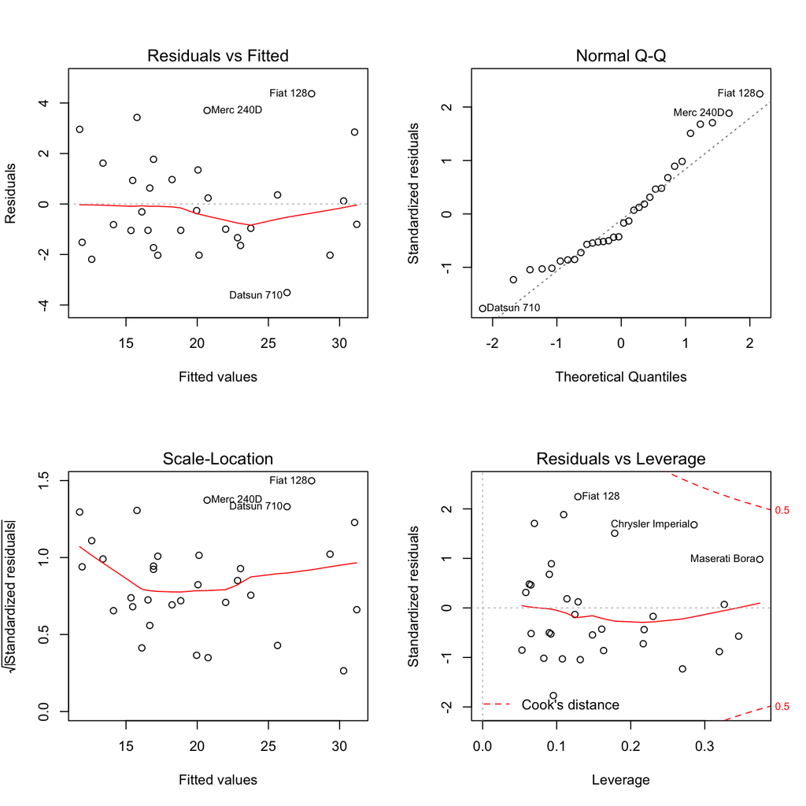

The plot shows:  
- no discernable patterns with residuals plotted against fitted values  
- points close to the line in QQ plot, hence close to normally distributed  
- no points exertng high leverage as outliers